# Homework2-Week4

Silvy van Kuijk

September 28, 2016

### Homework - Problem 2

#### [1] Calculate the population mean and standard deviation for each quantitative random variable (height, weight, age, number of zombies killed, and years of education). NOTE: You will not want to use the built in var() and sd() commands as these are for samples.

```r
path <- file.choose() #Choose your Zombies.csv file!
zombies <- read.csv(path, sep=",", header=TRUE)
```

I think this should all fit in one function:

```r
zombies.function <- function(x){
  zmean <- mean(x)
  zvar <- sum((x - mean(x)) ^2) / (length(x) -1)
  zsd <- sqrt(zvar)
  outcome <- paste("Mean = ", round(zmean, digits=2), ". Standard Deviation = ", round(zsd, digits=2), ".")
  outcome
}
#Now I can run the funtion for each of the columns of interest and it will first give you the mean, then the SD:

zombies.function(zombies$age)
```

```
## [1] "Mean =  20.05 . Standard Deviation =  2.97 ."
```

```r
zombies.function(zombies$height)
```

```
## [1] "Mean =  67.63 . Standard Deviation =  4.31 ."
```

```r
zombies.function(zombies$weight)
```

```
## [1] "Mean =  143.91 . Standard Deviation =  18.4 ."
```

```r
zombies.function(zombies$zombies_killed)
```

```
## [1] "Mean =  2.99 . Standard Deviation =  1.75 ."
```

```r
zombies.function(zombies$years_of_education)
```

```
## [1] "Mean =  3 . Standard Deviation =  1.68 ."
```

#### [2] Use ggplot and make boxplots of each of these variables by gender.

I think this could go in one function too…

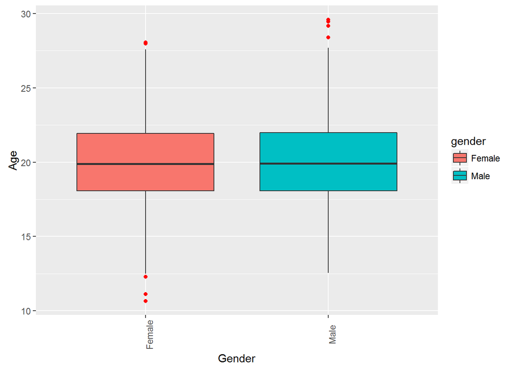

```r
library(ggplot2)
boxplot.function <- function(x,y){
bp <- ggplot(data=zombies, aes(x=gender, y=x, fill=gender))
bp <- bp + geom_boxplot(outlier.colour = "red")
bp <- bp + theme(axis.text.x=element_text(angle=90))
bp <- bp + ylab(y)
bp <- bp + xlab("Gender")
bp
}

boxplot.function(zombies$age,"Age")
```

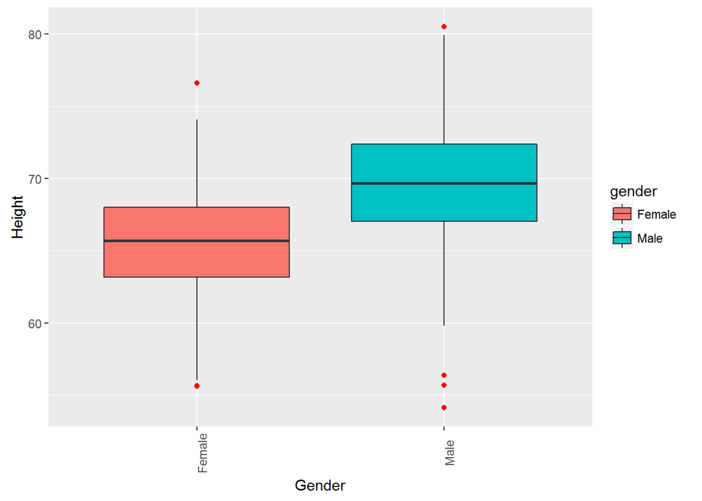

```r
boxplot.function(zombies$height, "Height")
```

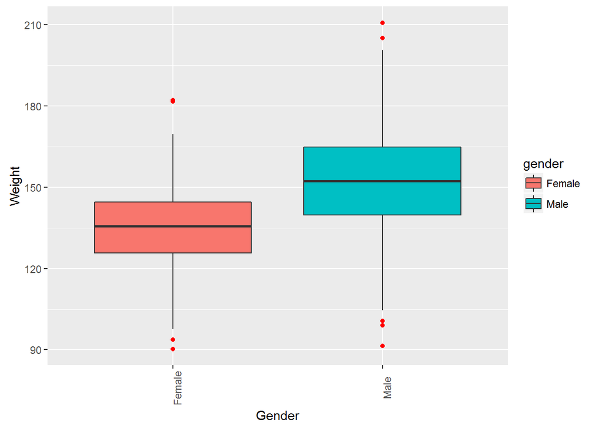

```r
boxplot.function(zombies$weight, "Weight")
```

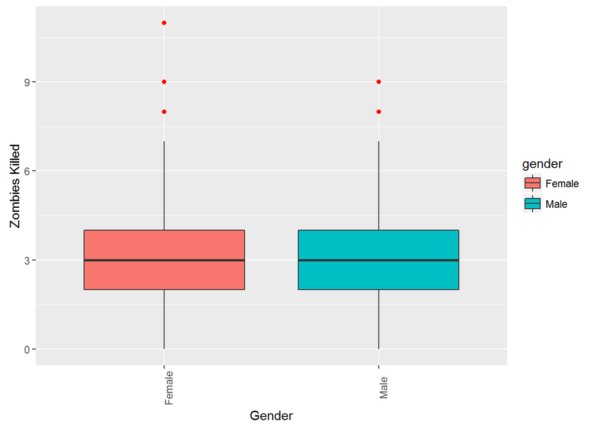

```r
boxplot.function(zombies$zombies_killed, "Zombies Killed")
```

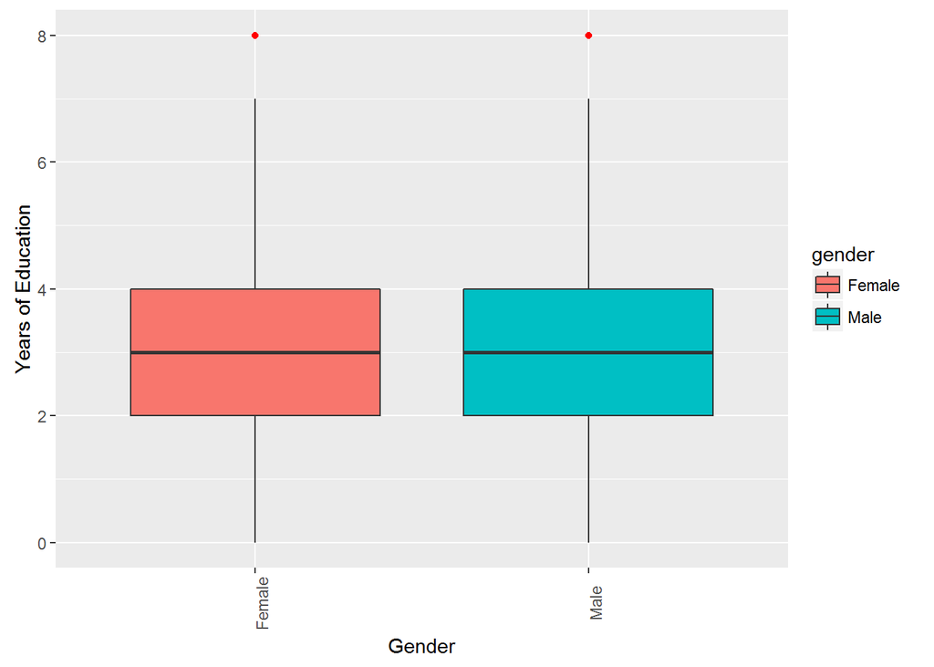

```r
boxplot.function(zombies$years_of_education, "Years of Education")
```

#### [3] Use ggplot and make scatterplots of height and weight in relation to age. Do these variables seem to be related? In what way?

Ggplot is awesome! You can make really nice looking plots…

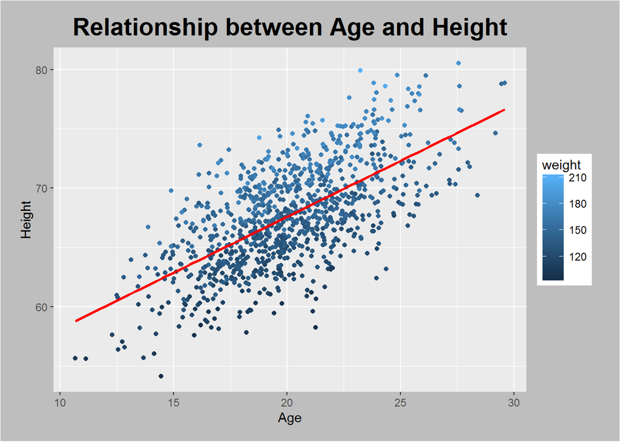

```r
sp <- ggplot(data=zombies, aes(x=age, y=height, color=weight)) + xlab("Age") + ylab("Height") + geom_point() + stat_smooth(method=lm, se=FALSE, color="red") + theme(plot.background=element_rect(fill="grey"), plot.title=element_text(size=20, face="bold", margin=margin(0, 0, 10, 0)), plot.margin=unit(c(0.5, 0.5, 0.5, 0.5), "cm")) + ggtitle("Relationship between Age and Height")
sp
```

or really ugly ones!

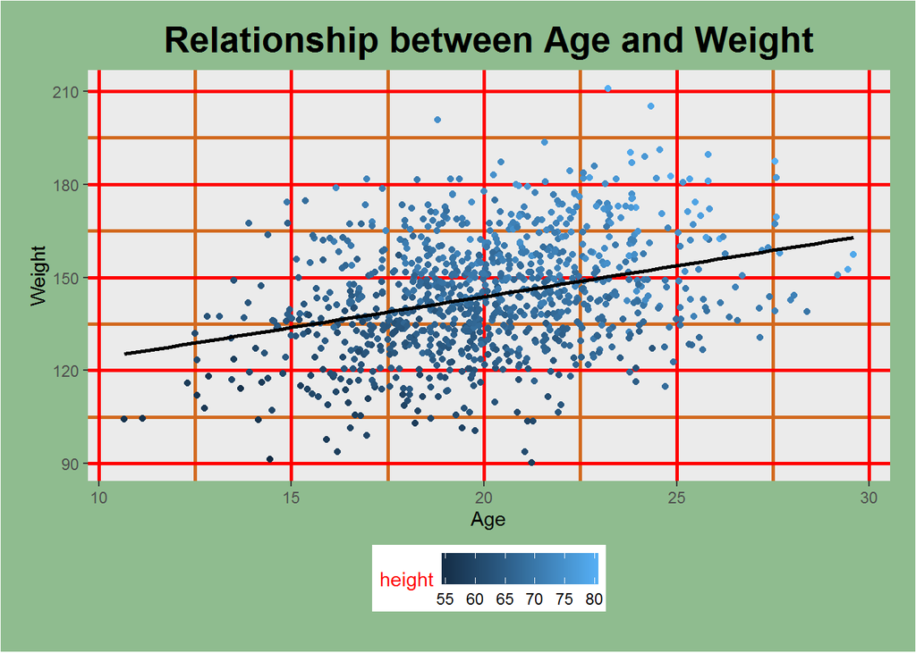

```r
sp <- ggplot(data=zombies, aes(x=age, y=weight, color=height)) + xlab("Age") + ylab("Weight") + geom_point() + theme(legend.position="bottom", legend.title=element_blank()) + stat_smooth(method=lm, se=FALSE, col="black") + theme(plot.background=element_rect(fill="darkseagreen"), plot.title=element_text(size=20, face="bold", margin=margin(0, 0, 10, 0)), legend.title = element_text(colour="red"), plot.margin=unit(c(0.5, 0.5, 0.5, 0.5), "cm"), panel.grid.major = element_line(color="red", size = 1), panel.grid.minor = element_line(color="chocolate", size = 1)) + ggtitle("Relationship between Age and Weight")
sp
```

These plots show that these variales are indeed related. As the zombies grow older, they grow taller and also increase their weight.

#### [4] Using histograms and Q-Q plots, check whether the quantitative variables seem to be drawn from a normal distribution. Which seem to be and which do not (hint: not all are drawn from the normal distribution)? For those that are not, can you determine what common distribution they are drawn from?

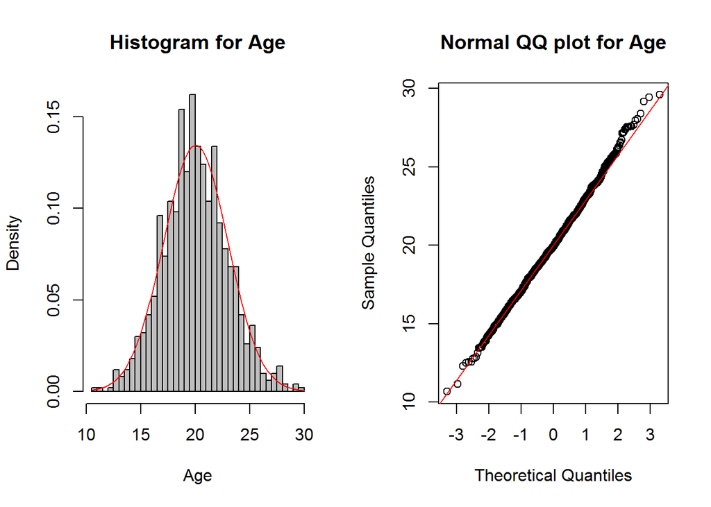

```r
par(mfrow = c(1, 2))
hist(zombies$age, breaks = 50, main="Histogram for Age", xlab="Age", prob=TRUE, col="grey")
curve(dnorm(x, mean=mean(zombies$age), sd=sd(zombies$age)), add=TRUE, col="red")

qqnorm(zombies$age, main="Normal QQ plot for Age")
qqline(zombies$age, col="red")
```

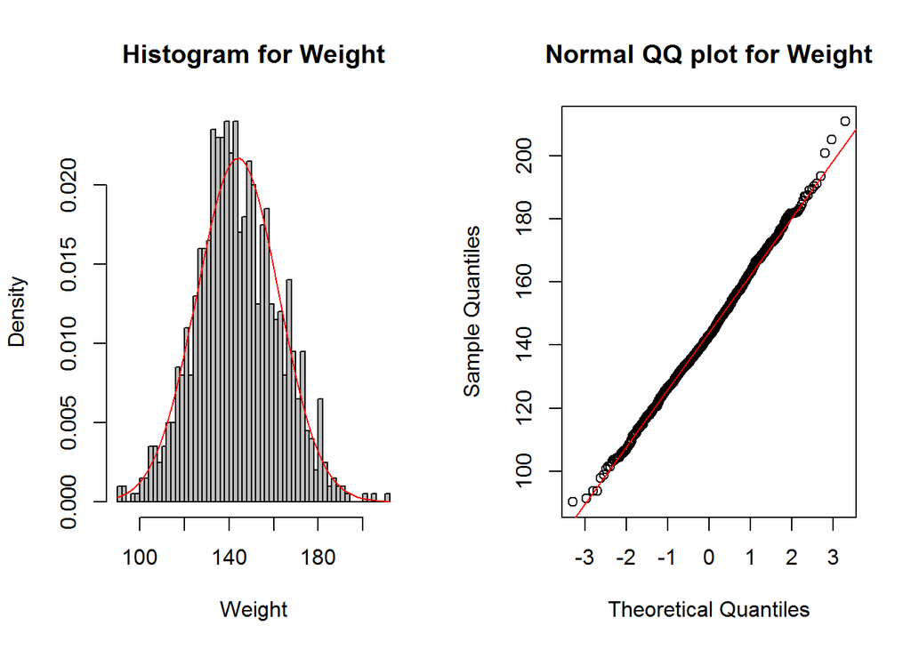

```r
par(mfrow = c(1, 2))
hist(zombies$weight, main="Histogram for Weight", xlab="Weight", prob=TRUE, breaks=50, col="grey")
curve(dnorm(x, mean=mean(zombies$weight), sd=sd(zombies$weight)), add=TRUE, col="red")

qqnorm(zombies$weight, main="Normal QQ plot for Weight")
qqline(zombies$weight, col="red")
```

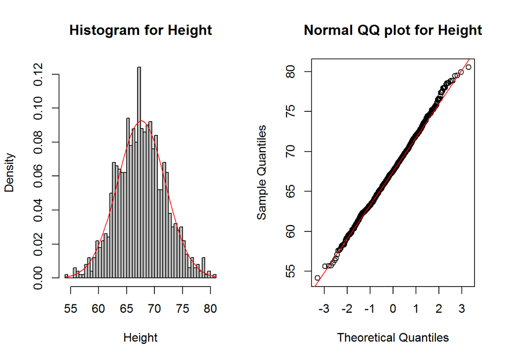

```r
par(mfrow = c(1, 2))
hist(zombies$height, main="Histogram for Height", xlab="Height", prob=TRUE, breaks=50, col="grey")
curve(dnorm(x, mean=mean(zombies$height), sd=sd(zombies$height)), add=TRUE, col="red")

qqnorm(zombies$height, main="Normal QQ plot for Height")
qqline(zombies$height, col="red")
```

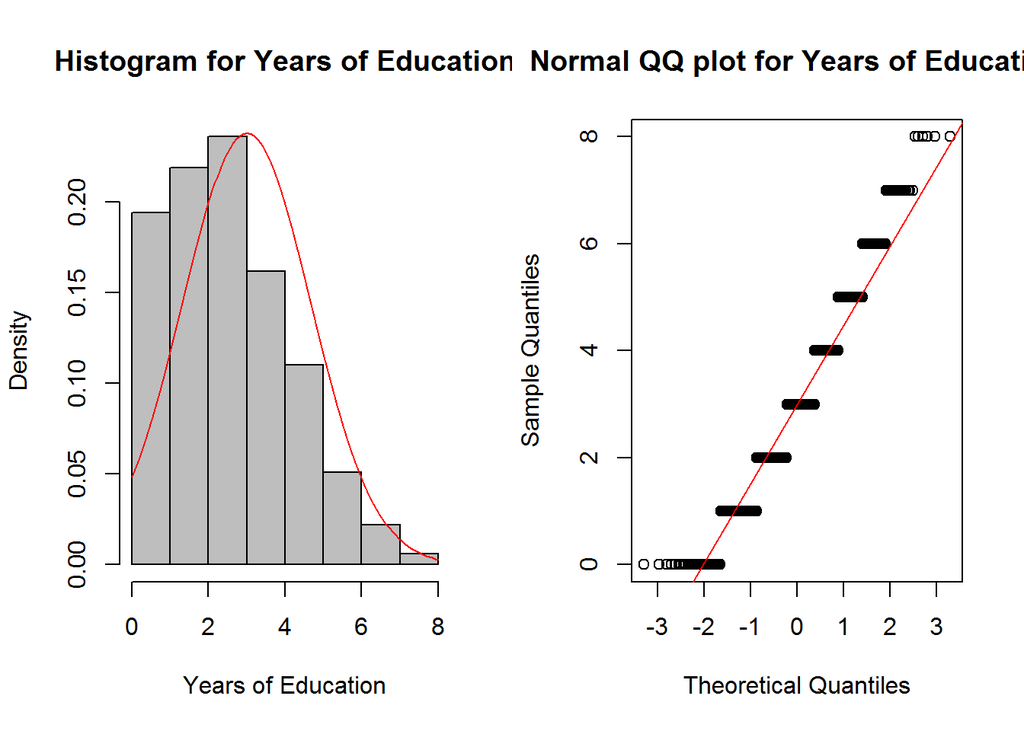

```r
par(mfrow = c(1, 2))
hist(zombies$years_of_education, main="Histogram for Years of Education", xlab="Years of Education", prob=TRUE, breaks=8, col="grey")
curve(dnorm(x, mean=mean(zombies$years_of_education), sd=sd(zombies$years_of_education)), add=TRUE, col="red")

qqnorm(zombies$years_of_education, main="Normal QQ plot for Years of Education")
qqline(zombies$years_of_education, col="red")
```

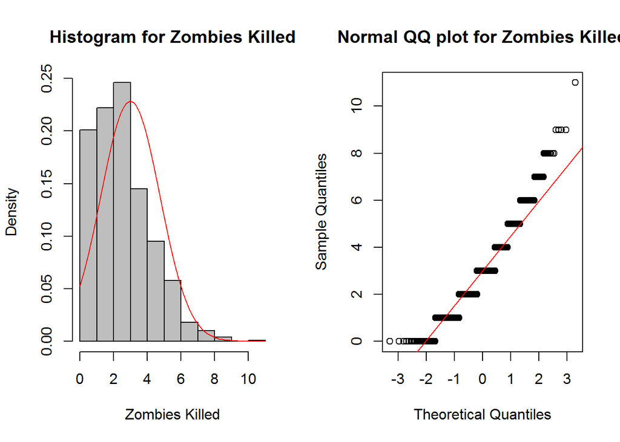

```r
par(mfrow = c(1, 2))
hist(zombies$zombies_killed, main="Histogram for Zombies Killed", xlab="Zombies Killed", prob=TRUE, breaks=10, col="grey")
curve(dnorm(x, mean=mean(zombies$zombies_killed), sd=sd(zombies$zombies_killed)), add=TRUE, col="red")

qqnorm(zombies$zombies_killed, main="Normal QQ plot for Zombies Killed")
qqline(zombies$zombies_killed, col="red")
```

The variables Years of Education and Zombies Killed are the only two that are not normally distributed. The first three variables - Age, Weight, and Height - are normally distributed, shown by the bell-curves in the Histograms and the data in the QQ plots being nicely on top of the line. The variables Years of Education and Zombies Killed do not fit the normal distribution, as shown by their skewed distribution in the histogram and the data not fitting perfectly on the line in the QQ plot. I think those variables may have a Poisson distribution because they are counts.

#### [5] Now use the sample() function to sample ONE subset of 30 zombies (without replacement) from this population and calculate the mean and sample standard deviation for each variable. Also estimate the standard error for each variable and construct the 95% confidence interval for each mean. Note that for the variables that are not drawn from the normal distribution, you will need to base your estimate of the CIs on some different distribution.

I know I should have different function for the last two variables, but I really don’t know how, so I’ve just used the normal distribution CI calculation, just to make sure I could get all of question 6 to work.

```r
subset.function <- function(x){
  n = 30
  subset <- zombies[sample(nrow(zombies), n, replace = FALSE), ]
  mean <- mean(subset[,x])
  var <- sum((subset[,x] - mean(subset[,x])) ^2) / (length(subset[,x]) -1)
  sd <- sqrt(var)
  se <- sd/sqrt(30)
  critical <- qnorm(0.975)*sd/sqrt(n)
  ci.lower <- mean-critical
  ci.upper <- mean+critical
  outcome <- data.frame(mean, sd, se, ci.lower, ci.upper)
}
```

#### Age

```r
age <- subset.function(13)
age
```

```
##       mean       sd        se ci.lower ci.upper
## 1 19.38774 2.832584 0.5171568 18.37413 20.40135
```

#### Height

```r
height <- subset.function(8)
height
```

```
##       mean       sd        se ci.lower ci.upper
## 1 67.69855 4.569317 0.8342393 66.06347 69.33363
```

#### Weight

```r
weight <- subset.function(9)
weight
```

```
##       mean       sd       se ci.lower ci.upper
## 1 136.1441 23.88719 4.361184 127.5963 144.6918
```

#### Zombies Killed

```r
zombies_killed <- subset.function(10)
zombies_killed
```

```
##       mean       sd        se ci.lower ci.upper
## 1 2.833333 1.391683 0.2540854 2.335335 3.331332
```

#### Years of Education

```r
years_of_education <- subset.function(11)
years_of_education
```

```
##       mean       sd        se ci.lower ci.upper
## 1 3.233333 1.633345 0.2982066 2.648859 3.817808
```

#### [6] Now drawn 99 more random samples of 30 zombies and calculate the mean for each of the these samples. Together with the first sample you drew out, you now have a set of 100 means for each variable (each based on 30 observations), which constitutes a sampling distribution for each variable. What are the means and standard deviations of this distribution for each variable? How do the standard deviations compare to the standard errors estimated in [5]? What do these sampling distributions look like? Are they normally distributed? What about for those variables that you concluded were not originally drawn from a normal distribution?

```r
zombie.samples <- function(x, first.subset){
  final.outp <- first.subset
  for (i in 1:99){
  subset <- zombies[sample(nrow(zombies), 30, replace = FALSE), ]
  output1 <- subset.function(x)  ## Create a new dataset from the new sample using your previous function
  final.outp <- rbind(final.outp, output1) ## Then you should join the new data.frame with the previous
  i <- i+1
  }
  return(final.outp)
}
```

#### Age

```r
BigAge <- zombie.samples(13, age)

mean(BigAge$mean)
```

```
## [1] 20.12214
```

```r
sd(BigAge$mean)
```

```
## [1] 0.5476761
```

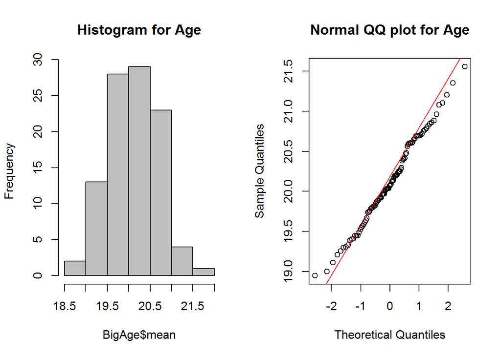

```r
par(mfrow = c(1, 2))
hist(BigAge$mean, main="Histogram for Age", col="grey")
qqnorm(BigAge$mean, main="Normal QQ plot for Age")
qqline(BigAge$mean, col="red")
```

#### Height

```r
BigHeight <- zombie.samples(8, height)

mean(BigHeight$mean)
```

```
## [1] 67.62602
```

```r
sd(BigHeight$mean)
```

```
## [1] 0.7985038
```

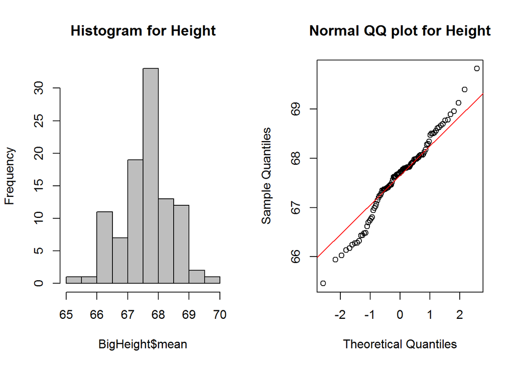

```r
par(mfrow = c(1, 2))
hist(BigHeight$mean, main="Histogram for Height", col="grey")
qqnorm(BigHeight$mean, main="Normal QQ plot for Height")
qqline(BigHeight$mean, col="red")
```

#### Weight

```r
BigWeight <- zombie.samples(9, weight)

mean(BigWeight$mean)
```

```
## [1] 144.0053
```

```r
sd(BigWeight$mean)
```

```
## [1] 3.313515
```

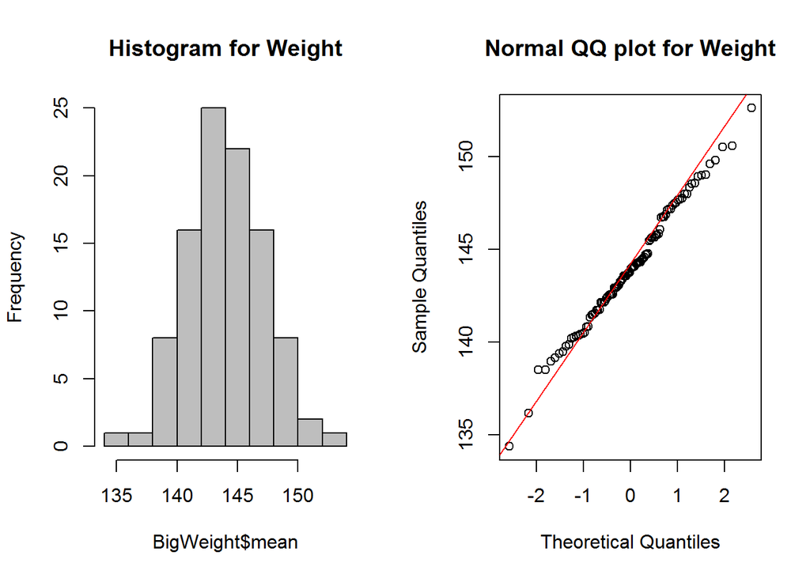

```r
par(mfrow = c(1, 2))
hist(BigWeight$mean, main="Histogram for Weight", col="grey")
qqnorm(BigWeight$mean, main="Normal QQ plot for Weight")
qqline(BigWeight$mean, col="red")
```

#### Zombies Killed

```r
Bigzombies_killed <- zombie.samples(10, zombies_killed)

mean(Bigzombies_killed$mean)
```

```
## [1] 3.031
```

```r
sd(Bigzombies_killed$mean)
```

```
## [1] 0.360423
```

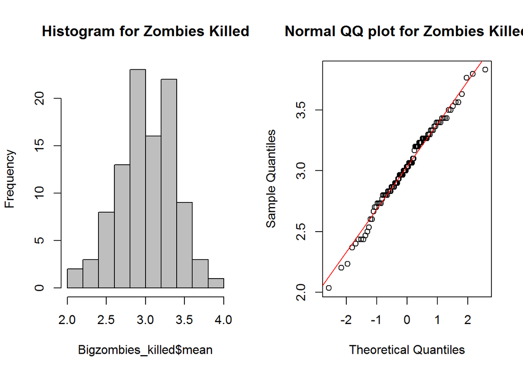

```r
par(mfrow = c(1, 2))
hist(Bigzombies_killed$mean, main="Histogram for Zombies Killed", col="grey")
qqnorm(Bigzombies_killed$mean, main="Normal QQ plot for Zombies Killed")
qqline(Bigzombies_killed$mean, col="red")
```

#### Years of Education

```r
BigEducation <- zombie.samples(11, years_of_education)

mean(BigEducation$mean)
```

```
## [1] 2.972333
```

```r
sd(BigEducation$mean)
```

```
## [1] 0.2904022
```

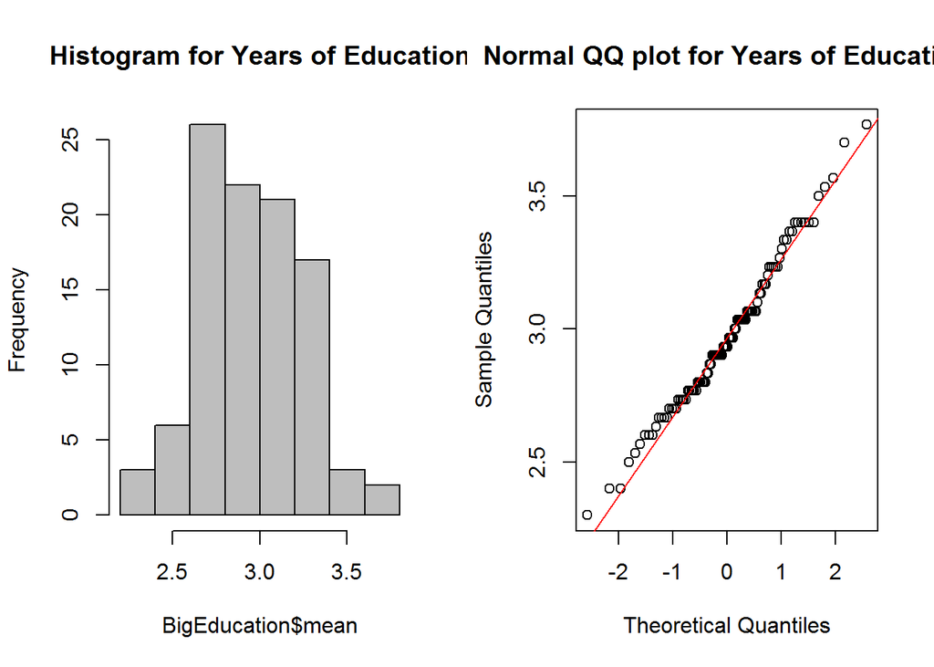

```r
par(mfrow = c(1, 2))
hist(BigEducation$mean, main="Histogram for Years of Education", col="grey")
qqnorm(BigEducation$mean, main="Normal QQ plot for Years of Education")
qqline(BigEducation$mean, col="red")
```

For all variables, the mean is very close to the population mean, and the standard deviation resembles the standard errors calculated in question 5. When you look at the histograms and QQ plots, you can see that all variables seem norally distributed.